# Lab 6 Tutorial | PAF 516

Spatio-Temporal Analysis — LISA Trajectories & Space-Time Moran’s I

**How to use this file**

**First time:** Click **Render** to see all results. Then run chunk by chunk to understand each step.

This file is for learning — do not edit it. When ready for the assignment, go to: [Lab 6 Assignment](https://antjam-howell.github.io/paf-516-labs/lab6-assignment.html)

```r
# ── One-time course environment setup ─────────────────────────────────────
# Sentinel lives in user home (~/.paf516_ready) — persists across all lab
# folders. renv restores ONCE for the entire course, not once per lab.
# To force re-install: delete ~/.paf516_ready and re-render.
if (!file.exists("~/.paf516_ready")) {
  if (!requireNamespace("renv", quietly = TRUE)) install.packages("renv")
  tmp <- tempfile(fileext = ".lock")
  download.file(
    url      = "https://raw.githubusercontent.com/AntJam-Howell/paf-516-labs/main/renv.lock",
    destfile = tmp, mode = "wb"
  )
  renv::restore(lockfile = tmp, prompt = FALSE)
  file.create("~/.paf516_ready")
}

library(tidyverse)
library(tidycensus)
library(sf)
library(spdep)
library(viridis)
library(patchwork)
```

```r
# Run ONCE: census_api_key("YOUR_KEY", install = TRUE), then restart R.
```

# Overview

Lab 5 answered **what changed** in Maricopa County between 2013 and 2019. Lab 6 asks the deeper question: **is change spatially structured?**

Three new analyses, all using the same 2013 and 2019 data from Lab 5:

1. **LISA trajectories** — classify each tract by how its cluster membership changed
2. **Space-time Moran’s I** — test whether change scores are spatially autocorrelated
3. **Three-point trend** — add a 2016 middle observation to distinguish sustained trends from noise

All three time points (2013, 2016, 2019) use 2010 TIGER/Line tract boundaries, so GEOIDs match cleanly across all three years.

# Step 1: Rebuild the Lab 5 Dataset

We reconstruct the `change_df` object using the same 3-variable index, pooled standardization, and 2013/2019 time points from Lab 5.

```r
# 3-variable economic hardship index — consistent across 2013, 2016, and 2019 ACS
hardship_vars <- c(
  pov_below50   = "C17002_002",   # Income-to-poverty ratio < 0.50
  pov_50to99    = "C17002_003",   # Income-to-poverty ratio 0.50–0.99
  pov_den       = "C17002_001",   # Poverty universe denominator
  unemp_num     = "B23025_005",   # Unemployed
  unemp_den     = "B23025_002",   # In labor force
  median_income = "B19013_001"    # Median household income
)
```

```r
# ── Load from shared data cache or pull from Census API ───────────────────
# Pre-built RDS files in /data/ are shared across Labs 5 and 6 — no duplicate
# API calls. If running outside the repo structure, the fallback pulls live.

load_or_pull <- function(rds_path, pull_fn) {
  if (file.exists(rds_path)) {
    readRDS(rds_path)
  } else {
    result <- pull_fn()
    dir.create(dirname(rds_path), showWarnings = FALSE, recursive = TRUE)
    saveRDS(result, rds_path)
    result
  }
}

# year = 2013: 2009–2013 ACS, 2010 TIGER/Line boundaries
tract_2013_raw <- load_or_pull(
  "../data/maricopa_tracts_2013.rds",
  function() get_acs(
    geography = "tract", variables = hardship_vars,
    state = "AZ", county = "Maricopa", year = 2013,
    survey = "acs5", geometry = TRUE, progress_bar = FALSE
  )
)

# year = 2019: 2015–2019 ACS, also 2010 TIGER/Line boundaries
tract_2019_raw <- load_or_pull(
  "../data/maricopa_tracts_2019.rds",
  function() get_acs(
    geography = "tract", variables = hardship_vars,
    state = "AZ", county = "Maricopa", year = 2019,
    survey = "acs5", geometry = TRUE, progress_bar = FALSE
  )
)
```

```r
# ── Offline fallback — run this block instead if the Census API is down ──
# Replace the get_acs() chunk above with these readRDS() calls.
# All datasets are pre-built and stored in data/ for offline use.
#
# tract_2013_raw <- readRDS("../data/maricopa_tracts_2013.rds")
# tract_2019_raw <- readRDS("../data/maricopa_tracts_2019.rds")
```

```r
# ── Reshape, compute rates, standardize on pooled scale ──────────────────
widen_and_rate <- function(df) {
  df %>%
    select(-moe) %>%
    pivot_wider(names_from = variable, values_from = estimate) %>%
    mutate(
      poverty_rate = (pov_below50 + pov_50to99) / pov_den,
      unemp_rate   = unemp_num / unemp_den
    ) %>%
    filter(!is.na(poverty_rate), !is.na(unemp_rate), !is.na(median_income))
}

tract_2013_wide <- widen_and_rate(tract_2013_raw)
tract_2019_wide <- widen_and_rate(tract_2019_raw)

r2013 <- tract_2013_wide %>% st_drop_geometry() %>%
  select(GEOID, poverty_rate, unemp_rate, median_income)
r2019 <- tract_2019_wide %>% st_drop_geometry() %>%
  select(GEOID, poverty_rate, unemp_rate, median_income)

vars_to_pool <- c("poverty_rate", "unemp_rate", "median_income")

# Pooled mean and SD across 2013 + 2019 combined
pooled_stats <- map_dfr(vars_to_pool, function(v) {
  vals <- c(r2013[[v]], r2019[[v]])
  tibble(variable = v, mean = mean(vals, na.rm = TRUE), sd = sd(vals, na.rm = TRUE))
})

apply_pooled_z <- function(df, stats) {
  for (v in stats$variable) {
    pm <- stats$mean[stats$variable == v]
    ps <- stats$sd[stats$variable == v]
    df[[paste0("z_", v)]] <- (df[[v]] - pm) / ps
  }
  df$z_median_income <- -1 * df$z_median_income
  df$hardship_index <- rowMeans(
    df[, c("z_poverty_rate", "z_unemp_rate", "z_median_income")],
    na.rm = TRUE)
  return(df)
}

r2013_z <- apply_pooled_z(r2013, pooled_stats)
r2019_z <- apply_pooled_z(r2019, pooled_stats)

# Join and compute change score
change_df <- tract_2019_wide %>%
  select(GEOID, NAME) %>%
  left_join(r2019_z %>% select(GEOID, hardship_2019 = hardship_index), by = "GEOID") %>%
  inner_join(r2013_z %>% select(GEOID, hardship_2013 = hardship_index), by = "GEOID") %>%
  mutate(hardship_change = hardship_2019 - hardship_2013)

cat("Tracts in change_df:", nrow(change_df), "\n")
```

```
Tracts in change_df: 904
```

```r
cat("Mean change 2013→2019:", round(mean(change_df$hardship_change), 3), "\n")
```

```
Mean change 2013→2019: -0.483
```

# Step 2: Build Spatial Weights Matrix

```r
# Queen contiguity, row-standardized — same approach as Lab 4
nb <- poly2nb(change_df, queen = TRUE)
w  <- nb2listw(nb, style = "W", zero.policy = TRUE)

cat("Weights matrix built.\n")
```

```
Weights matrix built.
```

```r
cat("Tracts with zero neighbors:", sum(card(nb) == 0), "\n")
```

```
Tracts with zero neighbors: 1
```

# Step 3: Run LISA on Both Periods

We classify each tract into HH/LL/HL/LH/NS separately for 2013 and 2019.

```r
# ── LISA on the 2013 economic hardship index ──────────────────────────────────────
lisa_2013 <- localmoran(change_df$hardship_2013, w, zero.policy = TRUE)

z13  <- scale(change_df$hardship_2013)[, 1]
wz13 <- lag.listw(w, z13, zero.policy = TRUE)
p13  <- lisa_2013[, "Pr(z != E(Ii))"]

change_df <- change_df %>%
  mutate(
    lisa_2013 = case_when(
      z13 > 0 & wz13 > 0 & p13 < 0.05 ~ "HH",
      z13 < 0 & wz13 < 0 & p13 < 0.05 ~ "LL",
      z13 > 0 & wz13 < 0 & p13 < 0.05 ~ "HL",
      z13 < 0 & wz13 > 0 & p13 < 0.05 ~ "LH",
      TRUE ~ "NS"
    )
  )

cat("2013 LISA distribution:\n")
```

```
2013 LISA distribution:
```

```r
print(table(change_df$lisa_2013))
```

```
 HH  HL  LH  LL  NS
162   5   5 146 586
```

```r
# ── LISA on the 2019 economic hardship index ──────────────────────────────────────
lisa_2019 <- localmoran(change_df$hardship_2019, w, zero.policy = TRUE)

z19  <- scale(change_df$hardship_2019)[, 1]
wz19 <- lag.listw(w, z19, zero.policy = TRUE)
p19  <- lisa_2019[, "Pr(z != E(Ii))"]

change_df <- change_df %>%
  mutate(
    lisa_2019 = case_when(
      z19 > 0 & wz19 > 0 & p19 < 0.05 ~ "HH",
      z19 < 0 & wz19 < 0 & p19 < 0.05 ~ "LL",
      z19 > 0 & wz19 < 0 & p19 < 0.05 ~ "HL",
      z19 < 0 & wz19 > 0 & p19 < 0.05 ~ "LH",
      TRUE ~ "NS"
    )
  )

cat("2019 LISA distribution:\n")
```

```
2019 LISA distribution:
```

```r
print(table(change_df$lisa_2019))
```

```
 HH  HL  LH  LL  NS
175   3   1 149 576
```

# Step 4: LISA Transition Matrix

```r
cat("── LISA Transition Matrix (rows = 2013, columns = 2019) ──\n")
```

```
── LISA Transition Matrix (rows = 2013, columns = 2019) ──
```

```r
trans_mat <- table(`2013` = change_df$lisa_2013, `2019` = change_df$lisa_2019)
print(trans_mat)
```

```
    2019
2013  HH  HL  LH  LL  NS
  HH 150   0   0   0  12
  HL   0   1   0   3   1
  LH   2   0   0   0   3
  LL   0   1   0 120  25
  NS  23   1   1  26 535
```

```r
cat("\n── As row proportions (% of 2013 category that ended in each 2019 category) ──\n")
```

```
── As row proportions (% of 2013 category that ended in each 2019 category) ──
```

```r
print(round(prop.table(trans_mat, margin = 1) * 100, 1))
```

```
    2019
2013   HH   HL   LH   LL   NS
  HH 92.6  0.0  0.0  0.0  7.4
  HL  0.0 20.0  0.0 60.0 20.0
  LH 40.0  0.0  0.0  0.0 60.0
  LL  0.0  0.7  0.0 82.2 17.1
  NS  3.9  0.2  0.2  4.4 91.3
```

# Step 5: Trajectory Classification

```r
# ── Classify each tract into a policy-relevant trajectory ────────────────
change_df <- change_df %>%
  mutate(
    trajectory = case_when(
      lisa_2013 == "HH" & lisa_2019 == "HH" ~ "Persistent HH",
      lisa_2013 != "HH" & lisa_2019 == "HH" ~ "Emerging HH",
      lisa_2013 == "HH" & lisa_2019 != "HH" ~ "Dissolving HH",
      lisa_2013 == "LL" & lisa_2019 == "LL" ~ "Persistent LL",
      lisa_2013 != "LL" & lisa_2019 == "LL" ~ "Emerging LL",
      lisa_2013 == "HL" | lisa_2019 == "HL" ~ "HL Outlier",
      TRUE                                   ~ "Stable NS"
    )
  )

cat("── Trajectory distribution ──\n")
```

```
── Trajectory distribution ──
```

```r
change_df %>%
  st_drop_geometry() %>%
  count(trajectory, sort = TRUE) %>%
  mutate(pct = round(100 * n / sum(n), 1)) %>%
  print()
```

```
# A tibble: 7 × 3
  trajectory        n   pct
  <chr>         <int> <dbl>
1 Stable NS       564  62.4
2 Persistent HH   150  16.6
3 Persistent LL   120  13.3
4 Emerging LL      29   3.2
5 Emerging HH      25   2.8
6 Dissolving HH    12   1.3
7 HL Outlier        4   0.4
```

# Step 6: Trajectory Map

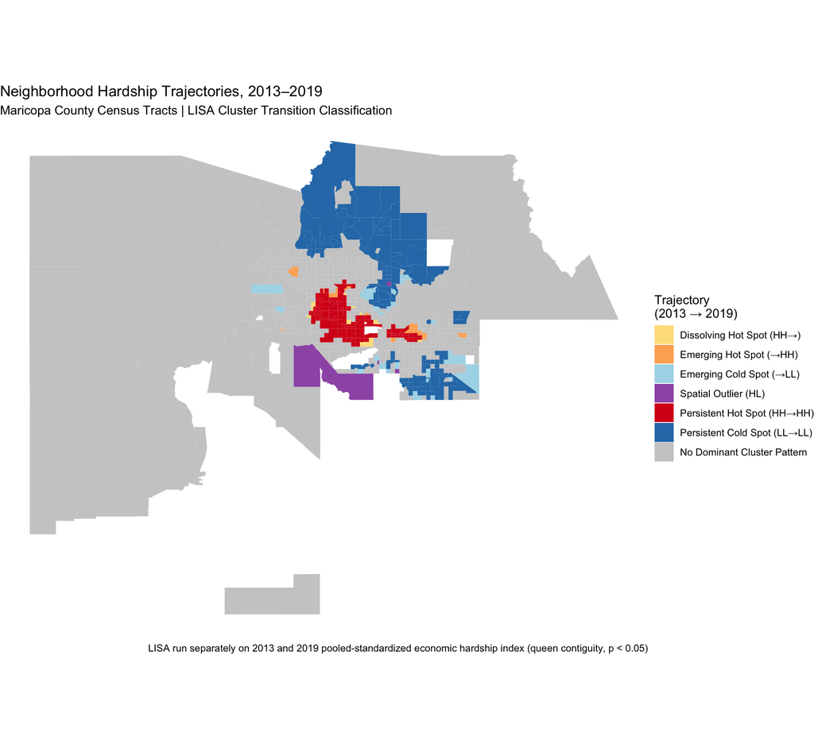

```r
traj_colors <- c(
  "Persistent HH"  = "#D7191C",
  "Emerging HH"    = "#FDAE61",
  "Dissolving HH"  = "#FEE08B",
  "Persistent LL"  = "#2C7BB6",
  "Emerging LL"    = "#ABD9E9",
  "HL Outlier"     = "#9E5BB4",
  "Stable NS"      = "#CCCCCC"
)

traj_labels <- c(
  "Persistent HH"  = "Persistent Hot Spot (HH→HH)",
  "Emerging HH"    = "Emerging Hot Spot (→HH)",
  "Dissolving HH"  = "Dissolving Hot Spot (HH→)",
  "Persistent LL"  = "Persistent Cold Spot (LL→LL)",
  "Emerging LL"    = "Emerging Cold Spot (→LL)",
  "HL Outlier"     = "Spatial Outlier (HL)",
  "Stable NS"      = "No Dominant Cluster Pattern"
)

ggplot(change_df) +
  geom_sf(aes(fill = trajectory), color = NA) +
  scale_fill_manual(values = traj_colors, labels = traj_labels,
                    name = "Trajectory\n(2013 → 2019)") +
  theme_void(base_size = 11) +
  labs(
    title    = "Neighborhood Hardship Trajectories, 2013–2019",
    subtitle = "Maricopa County Census Tracts | LISA Cluster Transition Classification",
    caption  = "LISA run separately on 2013 and 2019 pooled-standardized economic hardship index (queen contiguity, p < 0.05)"
  )
```

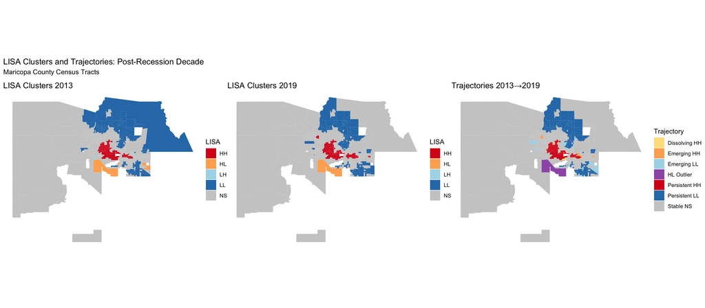

```r
# ── Side-by-side: 2013 LISA | 2019 LISA | Trajectories ───────────────────
lisa_colors <- c("HH" = "#D7191C", "LL" = "#2C7BB6",
                 "HL" = "#FDAE61", "LH" = "#ABD9E9", "NS" = "#CCCCCC")

p_l13 <- ggplot(change_df) +
  geom_sf(aes(fill = lisa_2013), color = NA) +
  scale_fill_manual(values = lisa_colors, name = "LISA") +
  theme_void() + labs(title = "LISA Clusters 2013")

p_l19 <- ggplot(change_df) +
  geom_sf(aes(fill = lisa_2019), color = NA) +
  scale_fill_manual(values = lisa_colors, name = "LISA") +
  theme_void() + labs(title = "LISA Clusters 2019")

p_traj <- ggplot(change_df) +
  geom_sf(aes(fill = trajectory), color = NA) +
  scale_fill_manual(values = traj_colors, name = "Trajectory") +
  theme_void() + labs(title = "Trajectories 2013→2019")

p_l13 + p_l19 + p_traj +
  plot_annotation(title    = "LISA Clusters and Trajectories: Post-Recession Decade",
                  subtitle = "Maricopa County Census Tracts")
```

# Step 7: Space-Time Moran’s I

Is the *change score itself* spatially autocorrelated? If tracts that improved cluster together and tracts that worsened cluster together, then decline and recovery are spreading processes — not random.

```r
set.seed(42)
moran_chg <- moran.mc(
  change_df$hardship_change,
  w,
  nsim         = 999,
  zero.policy  = TRUE
)

cat("── Space-Time Moran's I (applied to 2013→2019 change score) ──\n")
```

```
── Space-Time Moran's I (applied to 2013→2019 change score) ──
```

```r
cat("Moran's I:", round(moran_chg$statistic, 4), "\n")
```

```
Moran's I: 0.1347
```

```r
cat("p-value (permutation, 999 simulations):", round(moran_chg$p.value, 4), "\n")
```

```
p-value (permutation, 999 simulations): 0.001
```

```r
if (moran_chg$p.value < 0.05) {
  if (moran_chg$statistic > 0) {
    cat("\nInterpretation: SIGNIFICANT POSITIVE autocorrelation in change.\n")
    cat("Tracts that improved cluster together; tracts that worsened cluster together.\n")
    cat("Change is a spatially spreading process, not random.\n")
  } else {
    cat("\nInterpretation: SIGNIFICANT NEGATIVE autocorrelation.\n")
    cat("Improving and worsening tracts are spatially dispersed.\n")
  }
} else {
  cat("\nInterpretation: NOT SIGNIFICANT.\n")
  cat("Change is spatially random — driven by local factors, not spatial spread.\n")
}
```

```
Interpretation: SIGNIFICANT POSITIVE autocorrelation in change.
Tracts that improved cluster together; tracts that worsened cluster together.
Change is a spatially spreading process, not random.
```

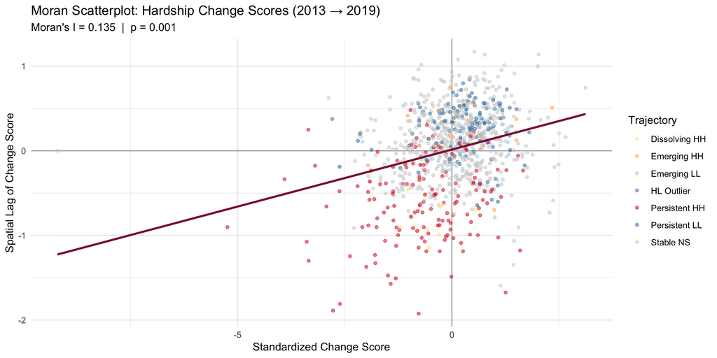

```r
# ── Moran scatterplot for the change score ────────────────────────────────
z_chg  <- scale(change_df$hardship_change)[, 1]
wz_chg <- lag.listw(w, z_chg, zero.policy = TRUE)

ggplot(tibble(z = z_chg, wz = wz_chg,
              trajectory = change_df$trajectory),
       aes(x = z, y = wz)) +
  geom_hline(yintercept = 0, color = "gray70") +
  geom_vline(xintercept = 0, color = "gray70") +
  geom_point(aes(color = trajectory), alpha = 0.5, size = 1.2) +
  geom_smooth(method = "lm", se = FALSE, color = "#8C1D40", linewidth = 1) +
  scale_color_manual(values = traj_colors) +
  theme_minimal() +
  labs(
    title    = "Moran Scatterplot: Hardship Change Scores (2013 → 2019)",
    subtitle = paste0("Moran's I = ", round(moran_chg$statistic, 3),
                      "  |  p = ", round(moran_chg$p.value, 3)),
    x        = "Standardized Change Score",
    y        = "Spatial Lag of Change Score",
    color    = "Trajectory"
  )
```

# Step 8: Three-Point Trend Analysis

Adding the 2012–2016 ACS (`year = 2016`) as a middle observation lets us distinguish sustained trends from endpoint noise. All three years — 2013, 2016, 2019 — use 2010 TIGER/Line tract boundaries.

```r
# year = 2016: 2012–2016 ACS | uses 2010 TIGER/Line boundaries (same as 2013 and 2019)
# Loads from shared cache if available — same load_or_pull() helper as Step 1
tract_2016_raw <- load_or_pull(
  "../data/maricopa_tracts_2016.rds",
  function() get_acs(
    geography    = "tract",
    variables    = hardship_vars,
    state        = "AZ",
    county       = "Maricopa",
    year         = 2016,
    survey       = "acs5",
    geometry     = FALSE,
    progress_bar = FALSE
  )
)
```

```r
# ── Offline fallback — run this block instead if the Census API is down ──
# Replace the get_acs() chunk above with these readRDS() calls.
# All datasets are pre-built and stored in data/ for offline use.
#
# tract_2016_raw <- readRDS("../data/maricopa_tracts_2016.rds")
```

```r
# ── Apply same pooled standardization (pooled_stats from Step 1) ──────────
tract_2016_wide <- widen_and_rate(tract_2016_raw %>% mutate(geometry = NULL))
r2016 <- tract_2016_wide %>% select(GEOID, poverty_rate, unemp_rate, median_income)
r2016_z <- apply_pooled_z(r2016, pooled_stats)

cat("2016 tracts with valid index:", nrow(r2016_z), "\n")
```

```
2016 tracts with valid index: 905
```

```r
# ── Join all three years; classify monotonicity ───────────────────────────
trend_df <- change_df %>%
  st_drop_geometry() %>%
  select(GEOID, hardship_2013, hardship_2019) %>%
  inner_join(r2016_z %>% select(GEOID, hardship_2016 = hardship_index),
             by = "GEOID") %>%
  mutate(
    trend_type = case_when(
      hardship_2013 > hardship_2016 & hardship_2016 > hardship_2019 ~ "Consistently improving",
      hardship_2013 < hardship_2016 & hardship_2016 < hardship_2019 ~ "Consistently worsening",
      hardship_2013 > hardship_2016 & hardship_2016 < hardship_2019 ~ "V-shaped (improved mid)",
      hardship_2013 < hardship_2016 & hardship_2016 > hardship_2019 ~ "Inverted-V (worsened mid)",
      TRUE ~ "Flat / non-monotone"
    )
  )

cat("── Three-point trend distribution (2013 | 2016 | 2019) ──\n")
```

```
── Three-point trend distribution (2013 | 2016 | 2019) ──
```

```r
trend_df %>%
  count(trend_type, sort = TRUE) %>%
  mutate(pct = round(100 * n / sum(n), 1)) %>%
  print()
```

```
# A tibble: 4 × 3
  trend_type                    n   pct
  <chr>                     <int> <dbl>
1 Consistently improving      577  63.9
2 Inverted-V (worsened mid)   195  21.6
3 V-shaped (improved mid)     100  11.1
4 Consistently worsening       31   3.4
```

```r
change_df <- change_df %>%
  left_join(trend_df %>% select(GEOID, trend_type), by = "GEOID")
```

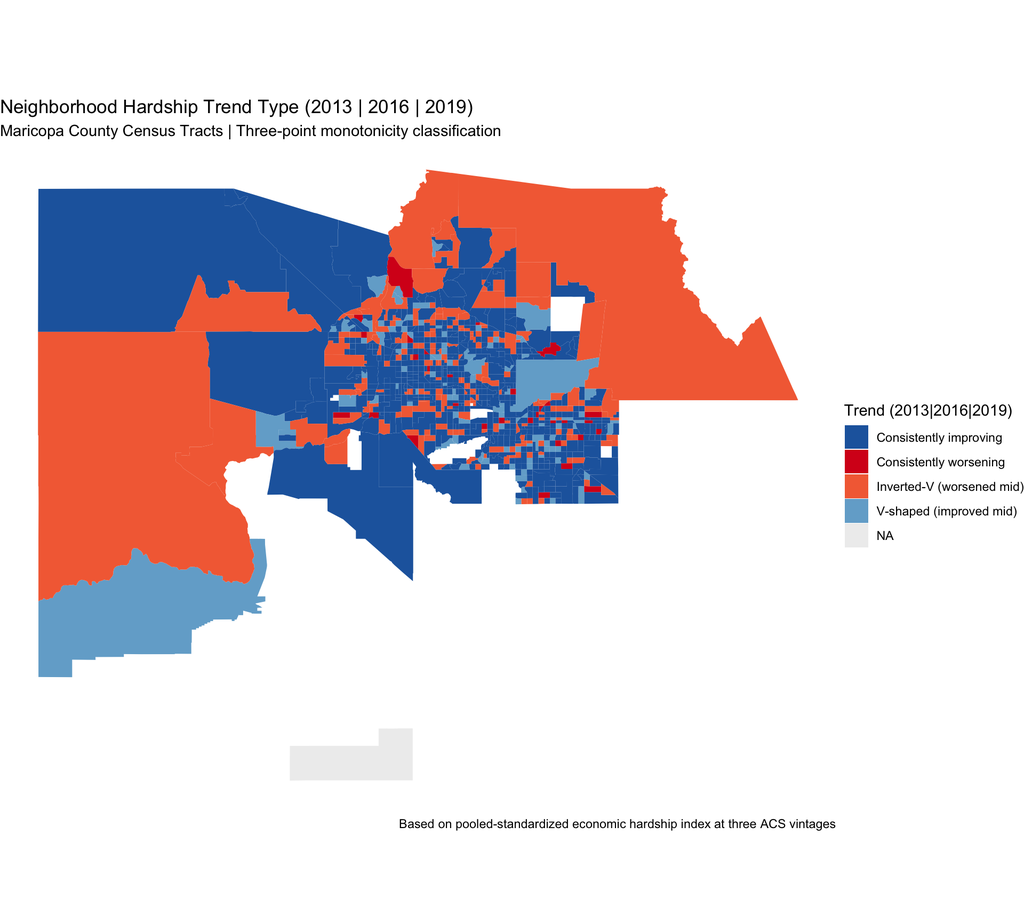

```r
trend_colors <- c(
  "Consistently improving" = "#2166AC",
  "Consistently worsening" = "#D7191C",
  "V-shaped (improved mid)"  = "#74ADD1",
  "Inverted-V (worsened mid)"  = "#F46D43",
  "Flat / non-monotone"      = "#CCCCCC"
)

ggplot(change_df) +
  geom_sf(aes(fill = trend_type), color = NA) +
  scale_fill_manual(values = trend_colors, na.value = "#EEEEEE",
                    name = "Trend (2013|2016|2019)") +
  theme_void(base_size = 11) +
  labs(
    title    = "Neighborhood Hardship Trend Type (2013 | 2016 | 2019)",
    subtitle = "Maricopa County Census Tracts | Three-point monotonicity classification",
    caption  = "Based on pooled-standardized economic hardship index at three ACS vintages"
  )
```

**Ready for the Assignment**

Head to the [Lab 6 Assignment](https://antjam-howell.github.io/paf-516-labs/lab6-assignment.html) to download `Lab6_Assignment.qmd`.